# SqlServerProfiler

Sql Server Profiler allows to read *XML exported files from MS SQL Server Profiler* TRC files.

Those trace files can have fields filtered using bash *NEW.XML files.

Those light files can be opened using MS Excel and be saved as *NEW.XLS files.

Sql Server Profiler allows also to read reagular *NEW.XLS result files from Sql queries.

SqlServerProfiler can read *NEW.XLS files into a a data frame to start treatment in R.

This also does the graphics and all for static objects on the data base.

## Important SQL server objects

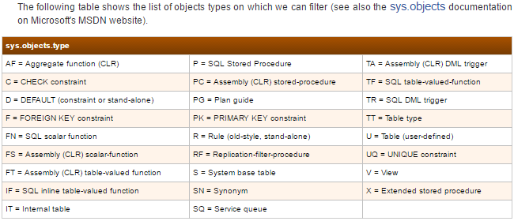

# R Session Info

## R Version info

R version 3.3.0 (2016-05-03)

Platform: x86_64-w64-mingw32/x64 (64-bit)

Running under: Windows >= 8 x64 (build 9200)

## Locale list

- LC_COLLATE=English_United States.1252
- LC_CTYPE=English_United States.1252
- LC_MONETARY=English_United States.1252
- LC_NUMERIC=C
- LC_TIME=English_United States.1252

## Base packages

- stats
- graphics
- grDevices
- utils
- datasets
- methods
- base

## Attached packages

- xlsx_0.5.7
- xlsxjars_0.6.1
- rJava_0.9-8
- wordcloud_2.5
- RColorBrewer_1.1-2
- tm_0.6-2
- NLP_0.1-9
- gridExtra_2.2.1
- ggplot2_2.1.0
- tibble_1.2-12
- data.table_1.9.8
- RevoUtilsMath_3.2.5

## Namespace packages-Not Attached

- Rcpp_0.12.8
- knitr_1.15.2
- magrittr_1.5
- munsell_0.4.3
- colorspace_1.2-6
- stringr_1.1.0
- plyr_1.8.4
- tools_3.3.0
- parallel_3.3.0
- grid_3.3.0
- gtable_0.2.0
- htmltools_0.3.5
- yaml_2.1.14
- assertthat_0.1
- rprojroot_1.1
- digest_0.6.10
- slam_0.1-34
- evaluate_0.10
- rmarkdown_1.2
- stringi_1.1.2
- scales_0.4.1
- backports_1.0.4

### Exclusion of liability

The code has been quickly written to publish a story as rapidy as possible. No guarantee is offered of its completeness, correctness or up-to-date nature. No liability is accepted for damage or loss incurred from the use of this script or the information drawn from it. This exclusion of liability also applies to third-party content that is accessible via this offer.

### License

[figure not shown]

Licensed under a [MIT License](https://raw.githubusercontent.com/enriqueescobar-askida/SqlServerProfiler/master/LICENSE).

### Contact details

Enrique dot Escobar @ Askida dot com